# Fit Data Analysis

Sachie Tran

9/23/2021

## Senario

You are a junior data analyst working on the marketing analyst team at Bellabeat, a high-tech manufacturer of health-focused products for women. Bellabeat is a successful small company, but they have the potential to become a larger player in the global smart device market. Urska Srsen, cofounder and Chief Creative Officer of Bellabeat, believes that analyzing smart device fitness data could help unlock new growth opportunities for the company. You have been asked to focus on one of Bellabeat’s products and analyze smart device data to gain insight into how consumers are using their smart devices. The insights you discover will then help guide marketing strategy for the company. You will present your analysis to the Bellabeat executive team along with your high-level recommendations for Bellabeat’s marketing strategy.

## Set up my environment

### Install packages and libraries

```r
#install.packages("tidyverse")
library(tidyverse)
#install.packages("dplyr")
library(dplyr)
```

### Import three dataframes

```r
daily_activity <- read_csv("dailyActivity_merged.csv")

sleep_day <- read_csv("sleepDay_merged.csv")

weight_log <- read_csv("weightLogInfo_merged.csv")
```

```r
head(daily_activity)
```

```
## # A tibble: 6 x 15
##        Id ActivityDate TotalSteps TotalDistance TrackerDistance LoggedActivitie~
##     <dbl> <chr>             <dbl>         <dbl>           <dbl>            <dbl>
## 1  1.50e9 4/12/2016         13162          8.5             8.5                 0
## 2  1.50e9 4/13/2016         10735          6.97            6.97                0
## 3  1.50e9 4/14/2016         10460          6.74            6.74                0
## 4  1.50e9 4/15/2016          9762          6.28            6.28                0
## 5  1.50e9 4/16/2016         12669          8.16            8.16                0
## 6  1.50e9 4/17/2016          9705          6.48            6.48                0
## # ... with 9 more variables: VeryActiveDistance <dbl>,
## #   ModeratelyActiveDistance <dbl>, LightActiveDistance <dbl>,
## #   SedentaryActiveDistance <dbl>, VeryActiveMinutes <dbl>,
## #   FairlyActiveMinutes <dbl>, LightlyActiveMinutes <dbl>,
## #   SedentaryMinutes <dbl>, Calories <dbl>
```

```r
head(sleep_day)
```

```
## # A tibble: 6 x 5
##          Id SleepDay           TotalSleepRecor~ TotalMinutesAsle~ TotalTimeInBed
##       <dbl> <chr>                         <dbl>             <dbl>          <dbl>
## 1    1.50e9 4/12/2016 12:00:0~                1               327            346
## 2    1.50e9 4/13/2016 12:00:0~                2               384            407
## 3    1.50e9 4/15/2016 12:00:0~                1               412            442
## 4    1.50e9 4/16/2016 12:00:0~                2               340            367
## 5    1.50e9 4/17/2016 12:00:0~                1               700            712
## 6    1.50e9 4/19/2016 12:00:0~                1               304            320
```

```r
head(weight_log)
```

```
## # A tibble: 6 x 8
##         Id Date       WeightKg WeightPounds   Fat   BMI IsManualReport     LogId
##      <dbl> <chr>         <dbl>        <dbl> <dbl> <dbl> <lgl>              <dbl>
## 1   1.50e9 5/2/2016 ~     52.6         116.    22  22.6 TRUE             1.46e12
## 2   1.50e9 5/3/2016 ~     52.6         116.    NA  22.6 TRUE             1.46e12
## 3   1.93e9 4/13/2016~    134.          294.    NA  47.5 FALSE            1.46e12
## 4   2.87e9 4/21/2016~     56.7         125.    NA  21.5 TRUE             1.46e12
## 5   2.87e9 5/12/2016~     57.3         126.    NA  21.7 TRUE             1.46e12
## 6   4.32e9 4/17/2016~     72.4         160.    25  27.5 TRUE             1.46e12
```

## The goal of this project is to answer these questions;

- What are the desirable features for Bellabeat considering the current wearable device trend?  
- What feature can we add for better self-management?

## Clean/organize dataframes

### 1. Change date format

```r
daily_activity$ActivityDate <- as.Date(daily_activity$ActivityDate, format = "%m/%d/%Y")
head(daily_activity)
```

```
## # A tibble: 6 x 15
##        Id ActivityDate TotalSteps TotalDistance TrackerDistance LoggedActivitie~
##     <dbl> <date>            <dbl>         <dbl>           <dbl>            <dbl>
## 1  1.50e9 2016-04-12        13162          8.5             8.5                 0
## 2  1.50e9 2016-04-13        10735          6.97            6.97                0
## 3  1.50e9 2016-04-14        10460          6.74            6.74                0
## 4  1.50e9 2016-04-15         9762          6.28            6.28                0
## 5  1.50e9 2016-04-16        12669          8.16            8.16                0
## 6  1.50e9 2016-04-17         9705          6.48            6.48                0
## # ... with 9 more variables: VeryActiveDistance <dbl>,
## #   ModeratelyActiveDistance <dbl>, LightActiveDistance <dbl>,
## #   SedentaryActiveDistance <dbl>, VeryActiveMinutes <dbl>,
## #   FairlyActiveMinutes <dbl>, LightlyActiveMinutes <dbl>,
## #   SedentaryMinutes <dbl>, Calories <dbl>
```

```r
sleep_day$ActivityDate <- as.Date(sleep_day$SleepDay, format = "%m/%d/%Y")
sleep_day <- sleep_day[,c(1,6,3,4,5)]  # change the order and remove unnecessary columns
head(sleep_day)
```

```
## # A tibble: 6 x 5
##           Id ActivityDate TotalSleepRecords TotalMinutesAsleep TotalTimeInBed
##        <dbl> <date>                   <dbl>              <dbl>          <dbl>
## 1 1503960366 2016-04-12                   1                327            346
## 2 1503960366 2016-04-13                   2                384            407
## 3 1503960366 2016-04-15                   1                412            442
## 4 1503960366 2016-04-16                   2                340            367
## 5 1503960366 2016-04-17                   1                700            712
## 6 1503960366 2016-04-19                   1                304            320
```

```r
weight_log$ActivityDate <- as.Date(weight_log$Date, format = "%m/%d/%Y")
weight_log <- weight_log[,c(1,9,3,4,5,6,7,8)]  # Change the order and remove unnecessary columns.
head(weight_log)
```

```
## # A tibble: 6 x 8
##        Id ActivityDate WeightKg WeightPounds   Fat   BMI IsManualReport    LogId
##     <dbl> <date>          <dbl>        <dbl> <dbl> <dbl> <lgl>             <dbl>
## 1  1.50e9 2016-05-02       52.6         116.    22  22.6 TRUE            1.46e12
## 2  1.50e9 2016-05-03       52.6         116.    NA  22.6 TRUE            1.46e12
## 3  1.93e9 2016-04-13      134.          294.    NA  47.5 FALSE           1.46e12
## 4  2.87e9 2016-04-21       56.7         125.    NA  21.5 TRUE            1.46e12
## 5  2.87e9 2016-05-12       57.3         126.    NA  21.7 TRUE            1.46e12
## 6  4.32e9 2016-04-17       72.4         160.    25  27.5 TRUE            1.46e12
```

### 2. Data merging

```r
# Create a primary-key combined "Id" and "ActivityDate" in each dataframe

daily_activity$key <- paste(daily_activity$Id,daily_activity$ActivityDate)

sleep_day$key <- paste(sleep_day$Id,sleep_day$ActivityDate)

weight_log$key <- paste(weight_log$Id,weight_log$ActivityDate)
```

```r
all_data <- merge(daily_activity, sleep_day, by=c("key"), all=T)

dim(all_data)   # Check if any row is missing
```

```
## [1] 943  21
```

```r
all_data <- merge(all_data, weight_log, by=c("key"), all=T)

dim(all_data)  # Check if any row is missing
```

```
## [1] 943  29
```

```r
head(all_data)
```

```
##                     key       Id.x ActivityDate.x TotalSteps TotalDistance
## 1 1503960366 2016-04-12 1503960366     2016-04-12      13162          8.50
## 2 1503960366 2016-04-13 1503960366     2016-04-13      10735          6.97
## 3 1503960366 2016-04-14 1503960366     2016-04-14      10460          6.74
## 4 1503960366 2016-04-15 1503960366     2016-04-15       9762          6.28
## 5 1503960366 2016-04-16 1503960366     2016-04-16      12669          8.16
## 6 1503960366 2016-04-17 1503960366     2016-04-17       9705          6.48
##   TrackerDistance LoggedActivitiesDistance VeryActiveDistance
## 1            8.50                        0               1.88
## 2            6.97                        0               1.57
## 3            6.74                        0               2.44
## 4            6.28                        0               2.14
## 5            8.16                        0               2.71
## 6            6.48                        0               3.19
##   ModeratelyActiveDistance LightActiveDistance SedentaryActiveDistance
```

[output cut: 34 more lines]

```r
# Reorganize and remove unnecessary columns

fit_data <- all_data[,c(2,3,4,5,7,8,9,10,11,12,13,14,15,16,20,21,23,24,25,26,27)]
```

### Insights

- There is no data about communication(texting/calling)  
- Most people report their weights by manual. What can I find from the weight report?  
- How do sleep time and workout results relate each other?

## Analysis

### 1. See the correlation between body-weight scale frequency and exercise results

```r
# Add body-weight frequency column

fit_data$WeightPounds[is.na(fit_data$WeightPounds)] <-0  # replace NA with zero

fit_data <- fit_data %>%
  mutate(weight_record = case_when(
  WeightPounds > 0 ~ "Weighted",
  WeightPounds == 0 ~ "not_Weighted"
  ))

fit_data <- mutate(fit_data, count = case_when(weight_record == 'not_Weighted'~ 0,weight_record == 'Weighted'~ 1))

head(fit_data)
```

```
##         Id.x ActivityDate.x TotalSteps TotalDistance LoggedActivitiesDistance
## 1 1503960366     2016-04-12      13162          8.50                        0
## 2 1503960366     2016-04-13      10735          6.97                        0
## 3 1503960366     2016-04-14      10460          6.74                        0
## 4 1503960366     2016-04-15       9762          6.28                        0
## 5 1503960366     2016-04-16      12669          8.16                        0
## 6 1503960366     2016-04-17       9705          6.48                        0
##   VeryActiveDistance ModeratelyActiveDistance LightActiveDistance
## 1               1.88                     0.55                6.06
## 2               1.57                     0.69                4.71
## 3               2.44                     0.40                3.91
## 4               2.14                     1.26                2.83
## 5               2.71                     0.41                5.04
## 6               3.19                     0.78                2.51
##   SedentaryActiveDistance VeryActiveMinutes FairlyActiveMinutes
```

[output cut: 20 more lines]

```r
weight_track <- fit_data %>%
  select(Id.x,weight_record) %>%
  mutate(fit_data, count = case_when(weight_record == 'not_Weighted'~ 0,weight_record == 'Weighted'~ 1)) %>%
  group_by(Id.x) %>%
  summarize(weighted=sum(count))

# Data validation in weight_data with fit_data

tail(weight_track, n=5)
```

```
## # A tibble: 5 x 2
##         Id.x weighted
##        <dbl>    <dbl>
## 1 8253242879        0
## 2 8378563200        0
## 3 8583815059        0
## 4 8792009665        0
## 5 8877689391       24
```

```r
table(fit_data$weight_record[fit_data$Id.x ==8877689391])
```

```
##
## not_Weighted     Weighted
##            7           24
```

```r
# Add aggregate "TotalSteps" data by Id

step_data <- fit_data %>%
  group_by(Id.x) %>%
  summarise(steps=sum(TotalSteps))
step_data
```

```
## # A tibble: 33 x 2
##          Id.x  steps
##         <dbl>  <dbl>
##  1 1503960366 375619
##  2 1624580081 178061
##  3 1644430081 218489
##  4 1844505072  79982
##  5 1927972279  28400
##  6 2022484408 352490
##  7 2026352035 172573
##  8 2320127002 146223
##  9 2347167796 171354
## 10 2873212765 234229
## # ... with 23 more rows
```

```r
# Add aggregate "Calories" data by Id

calory_data <- fit_data %>%
  group_by(Id.x) %>%
  summarise(total_calories=sum(Calories))
calory_data
```

```
## # A tibble: 33 x 2
##          Id.x total_calories
##         <dbl>          <dbl>
##  1 1503960366          56309
##  2 1624580081          45984
##  3 1644430081          84339
##  4 1844505072          48778
##  5 1927972279          67357
##  6 2022484408          77809
##  7 2026352035          47760
##  8 2320127002          53449
##  9 2347167796          36782
## 10 2873212765          59426
## # ... with 23 more rows
```

```r
# Merge two dataframes into one

weight_track <- merge(weight_track,step_data,by="Id.x")
weight_track <- merge(weight_track,calory_data,by="Id.x")
```

### Display a scatter plot of weight scale vs total steps

[figure not shown]

```r
library(scales)

ggplot(data=weight_track)+geom_point(mapping=aes(x=weighted, y=steps))+
  geom_smooth(mapping=aes(x=weighted, y=steps))+
  labs(title = "Weight Scale Frequency vs Total Steps",x = "Weight Scale (times)", y = "Steps (thousand)")+
    theme_minimal() +
  scale_y_continuous(labels = label_number(scale = 1e-3, accuracy = 1))
```

### Display a propotion table of weight scale and total steps

```r
step_table <- table(weight_track$weighted, cut(weight_track$steps, breaks=seq.int(from=0,to=500000,by=100000)))

step_table_prop <- prop.table(step_table)
round(step_table_prop,2)
```

```
##
##      (0,1e+05] (1e+05,2e+05] (2e+05,3e+05] (3e+05,4e+05] (4e+05,5e+05]
##   0       0.15          0.27          0.21          0.09          0.03
##   1       0.03          0.00          0.03          0.00          0.00
##   2       0.00          0.00          0.06          0.03          0.00
##   5       0.00          0.00          0.03          0.00          0.00
##   24      0.00          0.00          0.00          0.00          0.03
##   30      0.00          0.00          0.00          0.03          0.00
```

### Insights

- People who track their weight seem to walk more than who don’t.

### Display a scatter plot of weight scale vs total calories

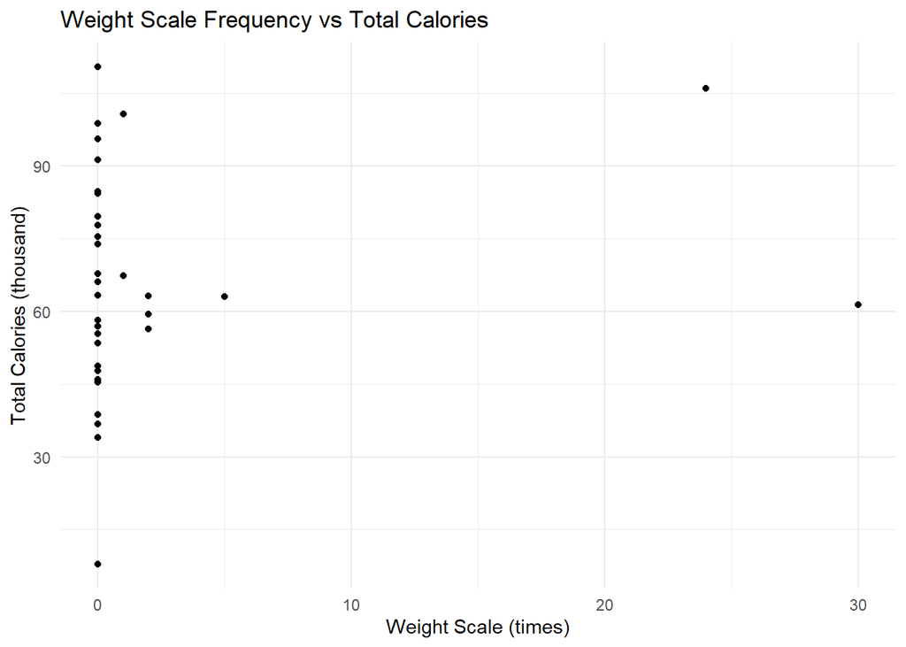

```r
ggplot(data=weight_track)+geom_point(mapping=aes(x=weighted, y=total_calories))+
  labs(title = "Weight Scale Frequency vs Total Calories",x = "Weight Scale (times)", y = "Total Calories (thousand)")+
    theme_minimal() +
  scale_y_continuous(labels = label_number(scale = 1e-3, accuracy = 1))
```

### See the relationship between weight scale and total calories in a propotion of table

```r
cal_table <- table(weight_track$weighted, cut(weight_track$total_calories, breaks=seq.int(from=0,to=115000,by=20000)))

cal_table_prop <- prop.table(cal_table)
cal_table_prop
```

```
##
##       (0,2e+04] (2e+04,4e+04] (4e+04,6e+04] (6e+04,8e+04] (8e+04,1e+05]
##   0  0.03333333    0.10000000    0.26666667    0.23333333    0.16666667
##   1  0.00000000    0.00000000    0.00000000    0.03333333    0.00000000
##   2  0.00000000    0.00000000    0.06666667    0.03333333    0.00000000
##   5  0.00000000    0.00000000    0.00000000    0.03333333    0.00000000
##   24 0.00000000    0.00000000    0.00000000    0.00000000    0.00000000
##   30 0.00000000    0.00000000    0.00000000    0.03333333    0.00000000
```

```r
round(cal_table_prop,2)
```

```
##
##      (0,2e+04] (2e+04,4e+04] (4e+04,6e+04] (6e+04,8e+04] (8e+04,1e+05]
##   0       0.03          0.10          0.27          0.23          0.17
##   1       0.00          0.00          0.00          0.03          0.00
##   2       0.00          0.00          0.07          0.03          0.00
##   5       0.00          0.00          0.00          0.03          0.00
##   24      0.00          0.00          0.00          0.00          0.00
##   30      0.00          0.00          0.00          0.03          0.00
```

## 2. See the relationship between workout and sleep

### Add cumulative calories, steps and sleep time columns for each Id.

```r
fit_data$accum_calories <-
  ave(fit_data$Calories,fit_data$Id.x, FUN = cumsum)

# Add cumulative Very active distance column for each Ids
fit_data$accum_VeryActive <-
  ave(fit_data$VeryActiveDistance,fit_data$Id.x, FUN = cumsum)

# Add cumulative moderate active distance column for each Ids
fit_data$accum_ModeratedActive <-
  ave(fit_data$ModeratelyActiveDistance ,fit_data$Id.x, FUN = cumsum)

# Add cumulative light active distance column for each Ids
fit_data$accum_LightlyActive <-
  ave(fit_data$LightActiveDistance,fit_data$Id.x, FUN = cumsum)
```

```r
# Add cumulative step column for each Ids
fit_data$accum_steps <-
  ave(fit_data$TotalSteps,fit_data$Id.x, FUN = cumsum)

# Add cumulative sleeping time column for each Ids
fit_data$accum_sleep <-
  ave(fit_data$TotalMinutesAsleep,fit_data$Id.x, FUN = cumsum)

n_distinct(fit_data$Id.x)
```

```
## [1] 33
```

### See the relationship between active distance/minutes and time in asleep

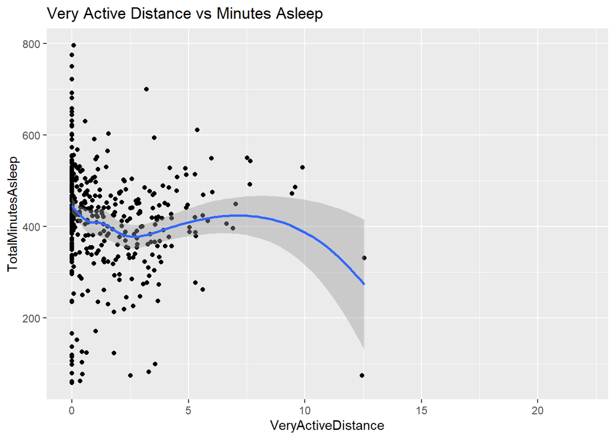

```r
# create scatter plot of very active distance vs minutes asleep
ggplot(fit_data,aes(x=VeryActiveDistance, y=TotalMinutesAsleep)) + geom_point()+
  geom_smooth(mapping=aes(x=VeryActiveDistance, y=TotalMinutesAsleep))+
  labs(title = "Very Active Distance vs Minutes Asleep")
```

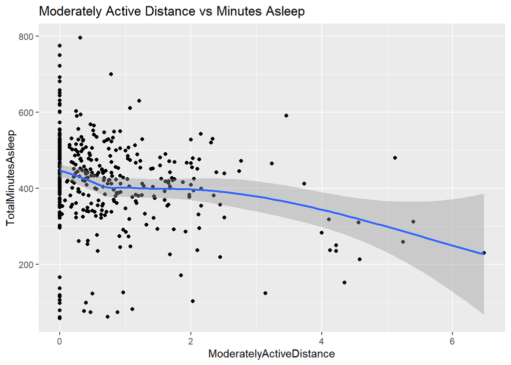

```r
# create a scatter plot of moderate active distance vs minutes asleep
ggplot(data=fit_data)+geom_point(mapping=aes(x=ModeratelyActiveDistance, y=TotalMinutesAsleep))+
  geom_smooth(mapping=aes(x=ModeratelyActiveDistance, y=TotalMinutesAsleep))+
  labs(title = "Moderately Active Distance vs Minutes Asleep")
```

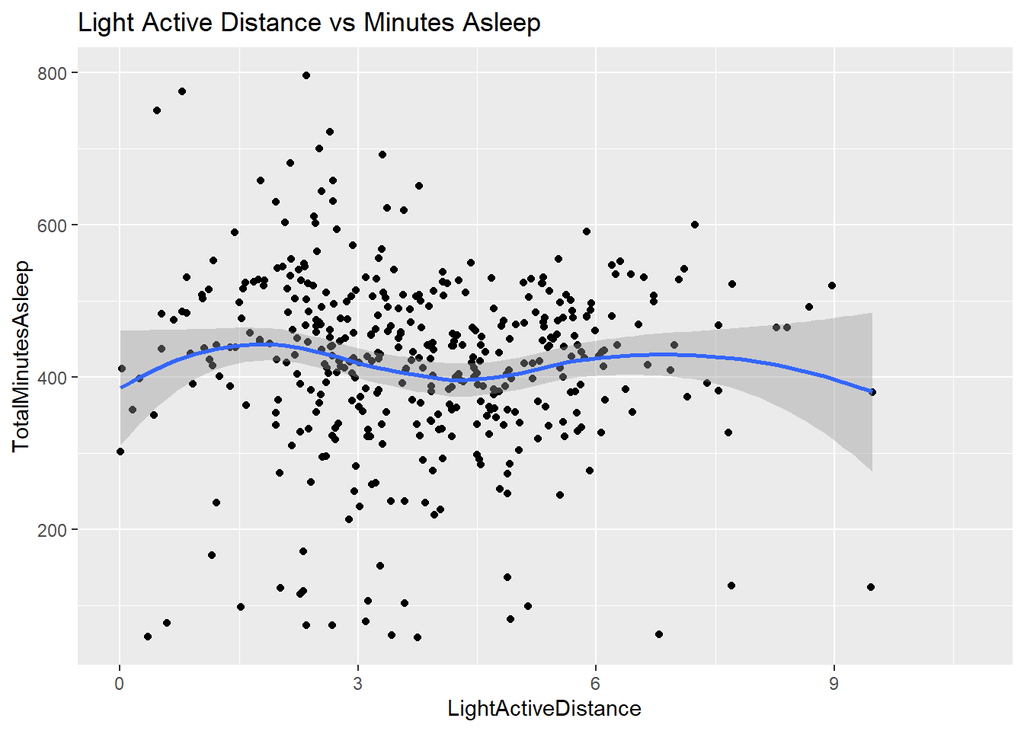

```r
# create a scatter plot of light active distance vs minutes asleep
ggplot(data=fit_data)+geom_point(mapping=aes(x=LightActiveDistance, y=TotalMinutesAsleep))+
  geom_smooth(mapping=aes(x=LightActiveDistance, y=TotalMinutesAsleep))+
  labs(title = "Light Active Distance vs Minutes Asleep")
```

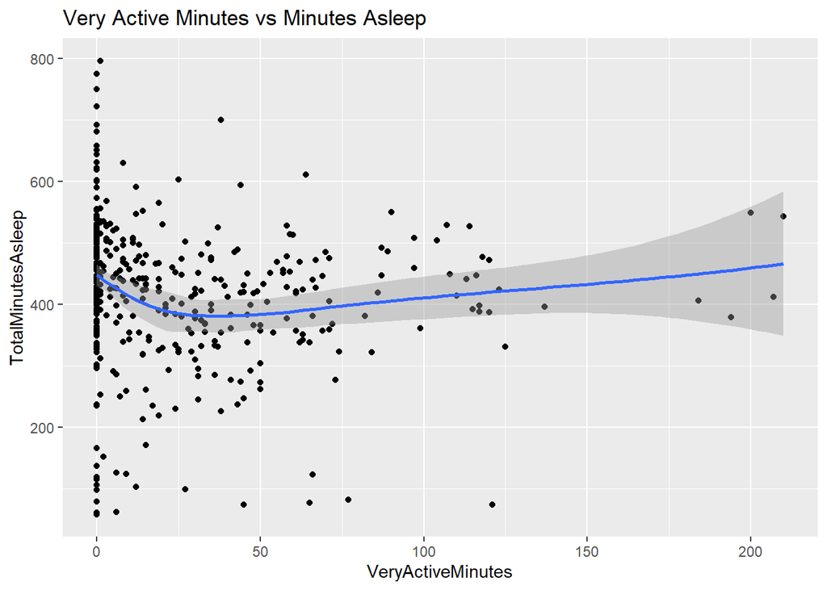

```r
# create a scatter plot of very active minutes and minutes asleep
ggplot(data=fit_data)+geom_point(aes(x=VeryActiveMinutes, y=TotalMinutesAsleep))+
  geom_smooth(mapping=aes(x=VeryActiveMinutes, y=TotalMinutesAsleep))+
  labs(title = "Very Active Minutes vs Minutes Asleep")
```

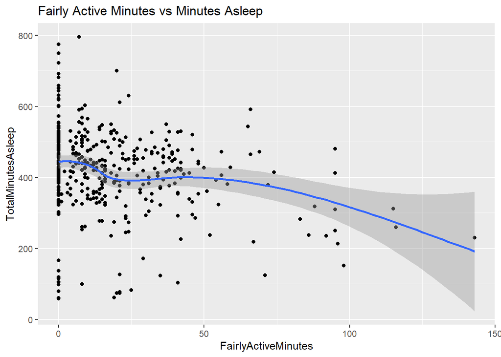

```r
ggplot(data=fit_data)+geom_point(mapping=aes(x=FairlyActiveMinutes, y=TotalMinutesAsleep))+
  geom_smooth(mapping=aes(x=FairlyActiveMinutes, y=TotalMinutesAsleep))+
  labs(title = "Fairly Active Minutes vs Minutes Asleep")
```

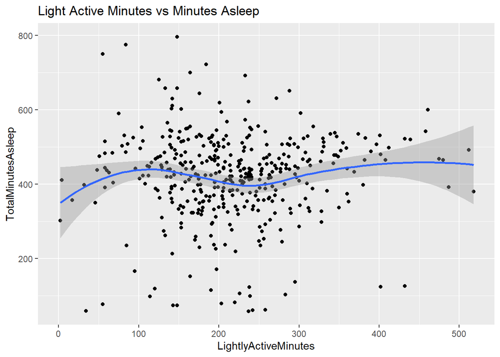

```r
ggplot(data=fit_data)+geom_point(mapping=aes(x=LightlyActiveMinutes, y=TotalMinutesAsleep))+
  geom_smooth(mapping=aes(x=LightlyActiveMinutes, y=TotalMinutesAsleep))+
  labs(title = "Light Active Minutes vs Minutes Asleep")
```

### Insights

- There is no obvious relationship between active distance/minutes and time in asleep.

## 3. See the relationship between burned calories and time in asleep

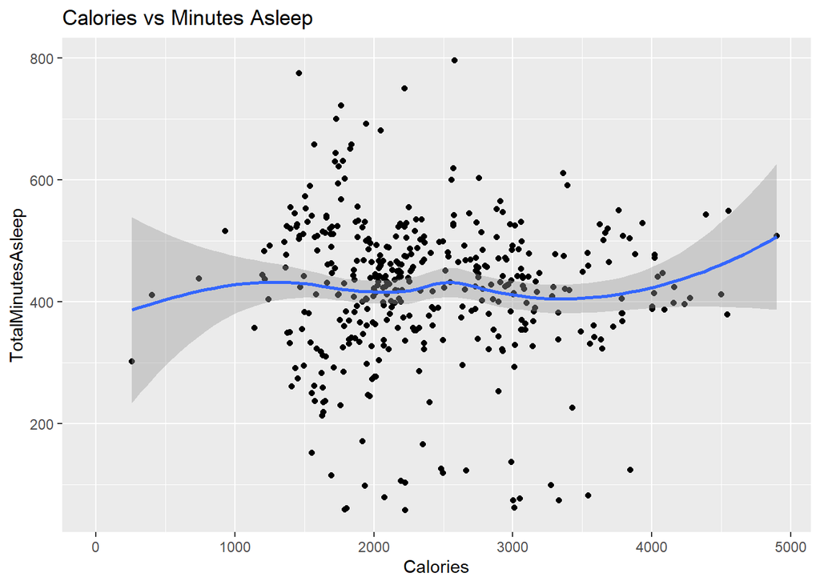

```r
ggplot(data=fit_data)+geom_point(mapping=aes(x=Calories, y=TotalMinutesAsleep))+
  geom_smooth(mapping=aes(x=Calories, y=TotalMinutesAsleep))+
  labs(title = "Calories vs Minutes Asleep")
```

### Insights

- There is no obvious relationship between calories and time in asleep.

## 4. See the relationship between steps and time in asleep

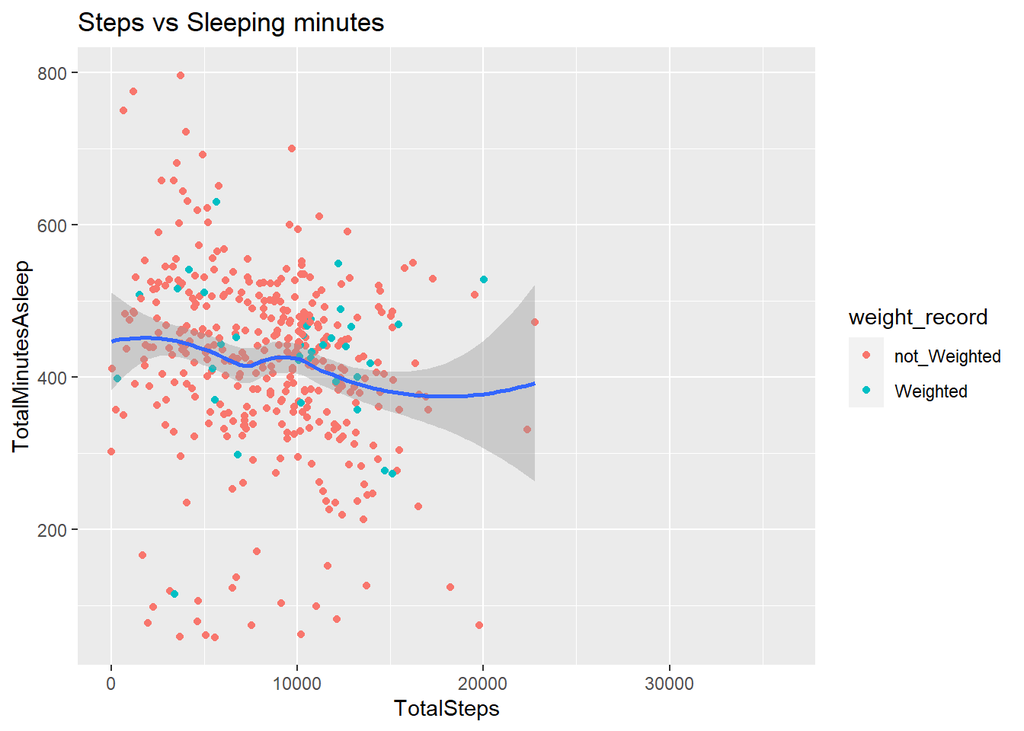

```r
scat1 <- ggplot(data=fit_data)+geom_point(mapping=aes(x=TotalSteps, y=TotalMinutesAsleep, color = weight_record))+
  geom_smooth(mapping=aes(x=TotalSteps, y=TotalMinutesAsleep))+
  labs(title = "Steps vs Sleeping minutes")
plot(scat1)
```

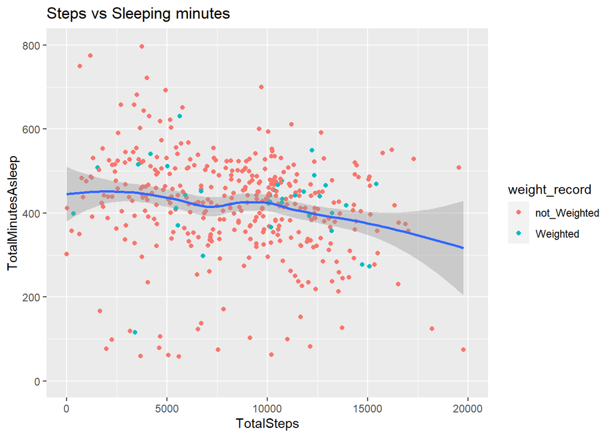

```r
scat2 <- scat1 + xlim(0,20000) + ylim(0,800)
plot(scat2)
```

### Insights

- There is no obvious relationship between steps and time in asleep.

## Next steps

Overall, I recommend Bellabeat marketing & tech team to improve weight-scale tracker feature by adding notification and auto-sync with a body weight scale to the device, and do the tests for the new features. These new features will lead users to focus more on their health. Do A/B test by asking their users to be a part of the survey and review the result.